# Section Draft — The model

Draft of the paper’s model section: the overview, then the model module by module with its key equations, the region × asset portfolio problem in full, the external closures, the empirical capital and ecological coefficients, and the model’s dynamical structure. The full equation listing is Supplementary Appendix 1.

**Note**

**What this page is.** A draft of the paper’s model section. It replaces the manuscript’s *Model Overview* (which moves here from the Background) and its *Descriptive Statistics* section, whose MRIO accounting now opens the production module. The model is presented in seven **modules**, each grouping blocks of the full description; each module gives the equations that carry its argument, numbered as in Supplementary Appendix 1, which consolidates the overview, the model description and the full equation listing. The calibration is a separate section, after this one.

## Background and literature

In recent years, several authors (e.g., Hardt and O’Neill, 2017; Bimpizas-Pinis et al., 2023; Fevereiro et al., 2025) have identified the combination of input–output (IO) analysis and stock-flow consistent (SFC) modelling as one of the most promising approaches for modelling the economy–ecology nexus, including circular-economy (CE) transition scenarios. IO models represent the interdependencies between the industries of a capitalist economy (Leontief, 1936, 1941): how a change in one industry’s production or consumption propagates through the system of inputs and outputs. SFC models replicate the dynamics of a financially sophisticated economy (Godley and Lavoie, 2007; Caverzasi and Godin, 2015; Nikiforos and Zezza, 2017), and have gained traction in ecological macroeconomics because they integrate the flows and stocks of the real economy, the financial sector and the ecosystem consistently (Dafermos et al., 2017, 2018; Carnevali et al., 2019, 2020, 2023).

Multi-regional IO models capture inter-industry linkages and cross-border footprints but are static and silent on distribution and finance; ecological SFC models capture macro-financial dynamics and distribution but on aggregated production structures. Only a few studies embed an IO structure in an SFC framework, and only one in a multi-regional setting (Berg et al., 2015; Valdecantos and Valentini, 2017; Veronese Passarella, 2023; Fevereiro et al., 2023; Di Domenico et al., 2024; Thomsen et al., 2025; Jackson and Jackson, 2025; Pettena and Raberto, 2025). Veronese Passarella (2023) disaggregated an SFC model both across institutional sectors and across industries and used it for simple CE scenarios; Fevereiro et al. (2023) extended it to two areas, with trade, supply chains, cross-border portfolios and exchange rates. This paper develops that line into a two-region ecological MRIO-SFC model with channel-specific CE interventions, primary-to-secondary substitution, and cross-border macro-financial linkages.

## The model at a glance

The model has two regions of 54 industries each, built from EXIOBASE 3.8.2 for 2011, and five institutional sectors per region: households, firms, commercial banks, a government and a central bank. The regional split is set by a concordance, not by the equations, which is how the same model runs as EU/RoW and as North/South. Every flow is a change in some sector’s balance sheet; each period is a year. Table 1 groups the thirteen blocks of the full description into seven modules, and says which parts follow post-Keynesian SFC convention and which do not.

Table 1. The modules of the model and the blocks of the full description (Supplementary Appendix 1).

| Module | Blocks | Conventional in post-Keynesian SFC models | Distinctive here |
| --- | --- | --- | --- |
| A. Production and the MRIO structure of demand | 2, 13 | Leontief quantities | Two-region MRIO; Armington origin choice on intermediate and final demand; empirical capital flows $K$ |
| B. Prices, distribution and money | 8, 4 | Endogenous, demand-led credit money | Sraffian prices of production with the Sraffa–Pivetti monetary closure of distribution |
| C. Households and labour | 1, 6 | Consumption out of income and wealth; two classes | — |
| D. Investment, finance and credit | 3 | Flexible accelerator | Empirical capital–output ratios; finance and credit terms measured against the unshocked path |
| E. Financial structure | 7 | Tobin–Godley–Lavoie portfolio | The full region × asset substitution matrix |
| F. Government, central banks and external closure | 5, 9, 10 | Government budget constraint; Godley–Lavoie open economy | An asymmetric reserve hierarchy; four alternative closures |
| G. Ecology | 11, 12 | Output-linked extensions | Empirical direct and total intensities of the targeted sectors |

## A. Production and the multi-regional structure of demand

**The accounting framework.** Table 2 is the compact accounting of the 108-sector system. Across a row: where a region’s output is sold, to industries as intermediate inputs (the $Z$ blocks) or to final users, by spending region. Down an industry column: its intermediate purchases and its value added. Every cell carries both a supplying and a using region, the bilateral structure through which an intervention in one region reaches the other.

Table 2. MRIO accounting: supplying regions in rows, using regions in columns. $D_{sr}$ is final demand for region $s$’s output purchased by region $r$; $\mathbf d_s = D_{s1} + D_{s2}$.

| Supplying region | EU industries | RoW industries | EU final demand | RoW final demand | Total final demand |
| --- | --- | --- | --- | --- | --- |
| EU | $Z_{11}$ | $Z_{12}$ | $D_{11}$ | $D_{12}$ | $\mathbf d_1$ |
| RoW | $Z_{21}$ | $Z_{22}$ | $D_{21}$ | $D_{22}$ | $\mathbf d_2$ |
| Value added | $\mathbf{VA}_1^{\top}$ | $\mathbf{VA}_2^{\top}$ |  |  |  |
| Total industry input | $\mathbf x_1^{\top}$ | $\mathbf x_2^{\top}$ |  |  |  |

**Final demand** addressed to each industry of either region sums household consumption, government consumption, private net investment, the replacement of worn-out capital and public investment, each split between domestic and foreign suppliers:

$$\mathbf{d}^z = \tilde{\mathbf{\beta}}^{Z1} c^{Z1} + \tilde{\mathbf{\beta}}^{Z2} c^{Z2} + \tilde{\mathbf{\sigma}}^{Z1} gov^{Z1} + \tilde{\mathbf{\sigma}}^{Z2} gov^{Z2} + \textstyle\sum_z \big[ \tilde{\mathbf{\iota}}^{z} (i_d^{z} - da^{z}) + K_{\cdot, z}\, \mathbf{x}^{z} \big] + \tilde{\mathbf{\iota}}_g^{Z1} i_{d,g}^{Z1} + \tilde{\mathbf{\iota}}_g^{Z2} i_{d,g}^{Z2} \qquad (2.1)$$

The share vectors have 108 entries, over both supplying regions, so imports are already inside $\mathbf d$. These shares are the instruments of the final-demand interventions. **Output** is the Leontief inverse applied to final demand, with the technical coefficients as operated: the technology set by the scenarios, whose split between domestic and foreign suppliers responds to relative buyer prices.

$$\mathbf{x}^z = \left( \mathbf{I} - \tilde{\mathbf{A}}^z \right)^{-1} \mathbf{d}^z \qquad (2.2)$$

$$\tilde{a}_{o,sj}^z = \big(a_{z,sj} + a_{f,sj}\big)\,\frac{a_{o,sj}\,\big(q^z_{a,o,s,-1}/q^z_{a,o,s,1}\big)^{-\varepsilon_{int}}}{\sum_{o'} a_{o',sj}\,\big(q^z_{a,o',s,-1}/q^z_{a,o',s,1}\big)^{-\varepsilon_{int}}},\qquad o \in \{z, f\},\ j \in z \qquad (13.3)$$

The input requirement $a_{z,sj} + a_{f,sj}$ is preserved; only its origin moves. The coefficients $a_{ij}$ are the instruments of the intermediate-demand interventions.

**Empirical capital stocks and flows.** Two coefficient sets from the data replace the uniform capital assumptions of the submitted model. The capital-flow matrix $K$ (EXIOBASE 2011, Södersten–Lenzen) gives what each industry’s depreciation consists of, by product and by origin; its column sums are the consumption of fixed capital per unit of output, $d_j$ (between 0.017 and 0.44). Replacement demand is the bundle $K\mathbf x$, which enters (2.1), and $K$ enters the price of production (module B). The target capital–output ratios are $\kappa_j = d_j/\delta_j$, with $\delta_j$ the Eurostat 2011 depreciation rate of the industry’s NACE section. In the EU they range from 0.15 to 5.0 (median 0.65; highest Renewable Electricity 5.0, Waste Incineration 3.3, Public Administration, Defence 3.2), and the firm capital stock is 1.75 (EU) and 1.74 (RoW) times net income in the baseline.

## B. Prices, distribution and money

Prices are Sraffian prices of production: one uniform rate of profit on the circulating and the fixed capital advanced, with each cross-border input valued at the exchange rate and the share of the import duty passed into the firm’s cost,

$$p^{z*} = w^z \oslash pr^z + (1+r)\, p^{*} \big[\Xi \odot (\tilde{A} + K)\big] \qquad (8.1)$$

$$\Xi = \Xi_{sj} = 1\ \ (s, j\ \text{same region}),\qquad \Xi_{sj} = xr^f\,(1 + \phi^z \tau_s^z)\ \ (s \in f,\ j \in z) \qquad (8.sraffian.7)$$

The rate of profit is the money rate of interest plus a normal profit of enterprise, the monetary closure of distribution that Pivetti (1991) proposed for Sraffa’s (1960) price system:

$$r = \frac{\sum_z r_{b,-1}^z VA_{-1}^z}{\sum_z VA_{-1}^z} + e \qquad (8.sraffian.4)$$

$e$ is derived, not fitted: the value at which the prices of production reproduce the observed 2011 price level. With the money wage anchored at its 2011 regional mean, the price level is determinate, and the wage and profit shares follow from prices, output and wages rather than from imposed mark-ups.

Money is endogenous and credit-led, in the horizontalist tradition: banks supply loans on demand, and deposits are created by lending; the central bank sets the policy rate, and every other rate is a mark-up on it.

$$L_s^z = L_F^z + L_h^z \qquad (4.1)$$

$$B_b^z = \beta_b^z M_s^z \qquad (4.3)$$

$$A_d^z = L_s^z + B_b^z - M_s^z \qquad (4.4)$$

$$r^{*z} = \bar{r}^{*z} + prem^z \qquad (5.9b)$$

$$r_l^z = r^{*z} + \mu_l^z \qquad (5.12)$$

Banks hold bills as a share of deposits, and advances from the central bank are the residual. The policy rate $r^{*}$ is exogenous except for a premium on the liabilities an intervention creates (module D), so the money rate of interest — and through (8.sraffian.4) the rate of profit — is set by the monetary authority.

## C. Households and labour

Workers and capitalists receive separate disposable incomes, and consumption has separate propensities out of each and out of wealth:

$$c^z = \alpha_1^z \frac{YD_w^z}{E(p_A^z)} + \alpha_2^z \frac{YD_c^z}{E(p_A^z)} + \alpha_3^z \frac{V_{-1}^z}{p_{A,-1}^z} \qquad (1.1)$$

$$YD_w^z = WB^z (1 - \theta_w^{eff,z}) \qquad (1.3)$$

$$YD_c^z = YD^z - YD_w^z \qquad (1.4)$$

Employment follows from sectoral labour coefficients; the labour force grows exogenously, and the immigration coefficients are zero in the reported results.

## D. Investment, finance and credit

Firms invest to close the gap between their capital stock and a target set by output and by their financial position:

$$k^{z*} = \frac{\mathbf{p}_{-1}^{zT}(\mathbf{h}^z\odot\mathbf{x}_{-1}^z)}{p_{I,-1}^z}\left\{1+\beta_m[(\rho-r_l)_{-1}^z-(\rho-r_l)_{-1}^{z,0}]-\beta_l[lev_{-1}^z-lev_{-1}^{z,0}]\right\} \qquad (3.1)$$

$$i_d^z = \gamma^z (k^{z*} - k_{-1}^z) + da^z - RAT^z / p_I^z \qquad (3.2)$$

with $h_j = \kappa_j$ from module A and $\gamma = 0.15$. The target falls when the margin of the profit rate over the loan rate narrows or leverage rises, both relative to the same arm’s unshocked path (superscript 0). Banks refuse a share of the *additional* loans a scenario makes firms ask for, and the refused part is investment that does not happen:

$$NL^{D,z} = (i_d^{D,z} - da^z) p_I^z + da^z p_{rep}^z - AF^z - FF_u^z - \Delta E_s^z \qquad (3.6a)$$

$$CR^z = \min\!\Big(CR_{max},\ \max\big(0,\ cr_0 + cr_1 (lev_{-1}^z - lev_{ref,-1}^z)\big)\Big) \qquad (3.6b)$$

$$RAT^z = \min\!\Big(\max(NL^{D,z},0),\ CR^z \max\big(NL^{D,z} - NL^{D,z}_{ref}, 0\big)\Big)\quad \Big[\text{ceiling: } \min\!\Big(\max(NL^{D,z},0),\ \max\big(0,\ \tfrac{L_{F,-1}^z + NL^{D,z} - L^{*z} p_I^z k^{D,z}}{1 - L^{*z}}\big)\Big),\ L^{*z} = lev_{ref}^z + h\Big] \qquad (3.6c)$$

Firm loans are the residual of the firms’ financing constraint, so leverage is set by households’ demand for equity (module E). All finance and credit terms are zero in the baseline and act only on what an intervention changes.

## E. Financial structure: the region × asset portfolio problem

Each region’s households allocate their wealth over five assets: bills issued by Z1 and by Z2 ($B_1$, $B_2$), equity issued by Z1 and by Z2 ($E_1$, $E_2$), and deposits ($M$). The share of asset $k$ in the wealth $V^z$ of holder $z$ is a constant plus a response to expected returns relative to their reference values:

$$\frac{A_{k}^{z}}{V^{z}} = \lambda^{0}_{z,k} + \big[\Lambda_z(\mathbf r^{e,z} - \bar{\mathbf r}_z)\big]_k,\qquad
\Lambda_z = \sigma\big(\operatorname{diag}\mathbf w_z - \mathbf w_z\mathbf w_z^{\top}\big),\qquad k \in \{B_1, B_2, E_1, E_2\}, \tag{7.1–7.4}$$

with cash a fixed share of lagged consumption and deposits the residual. $\mathbf w_z$ is holder $z$’s reference portfolio, $\bar{\mathbf r}_z$ the reference returns (both read from the end of the spin-up), $\mathbf r^{e,z}$ adaptive expected returns, $\mathbf r^{e}_t = \mathbf r^{e}_{t-1} + 0.1(\mathbf r_{t-1} - \mathbf r^{e}_{t-1})$, and each foreign asset’s return includes the realised currency gain. Written out for one holder,

$$\Lambda_z = \sigma
\begin{pmatrix}
w_{B_1}(1-w_{B_1}) & -w_{B_1}w_{B_2} & -w_{B_1}w_{E_1} & -w_{B_1}w_{E_2} & -w_{B_1}w_{M}\\
-w_{B_2}w_{B_1} & w_{B_2}(1-w_{B_2}) & -w_{B_2}w_{E_1} & -w_{B_2}w_{E_2} & -w_{B_2}w_{M}\\
-w_{E_1}w_{B_1} & -w_{E_1}w_{B_2} & w_{E_1}(1-w_{E_1}) & -w_{E_1}w_{E_2} & -w_{E_1}w_{M}\\
-w_{E_2}w_{B_1} & -w_{E_2}w_{B_2} & -w_{E_2}w_{E_1} & w_{E_2}(1-w_{E_2}) & -w_{E_2}w_{M}\\
-w_{M}w_{B_1} & -w_{M}w_{B_2} & -w_{M}w_{E_1} & -w_{M}w_{E_2} & w_{M}(1-w_{M})
\end{pmatrix}.$$

**Tobin’s constraints hold by construction.** Because $\sum_k w_k = 1$:

- **adding up:** every row and every column of $\Lambda_z$ sums to zero, so a change in returns reallocates wealth without creating or destroying it, and the five shares still sum to one;
- **symmetry:** $\Lambda_z = \Lambda_z^{\top}$, so the response of asset $k$ to the return on $j$ equals the response of $j$ to the return on $k$;
- **gross substitution:** the own-return entries $w_k(1-w_k)\sigma$ are positive and the cross-return entries $-w_kw_j\sigma$ negative;
- **neutrality at the reference:** at $\mathbf r^{e,z} = \bar{\mathbf r}_z$ the term vanishes and the portfolio is the calibrated one.

These are the conditions of Godley and Lavoie (2007, §5.6), here met by the functional form rather than by calibrating the 24 coefficients per region of the submitted model, which were all zero. Every index is the issuer: $\lambda^0_{z,B_1}$ is holder $z$’s share of wealth in bills issued by Z1, as the workbook’s `portfolio` sheet labels it. The arm runs $\sigma$ = 4.

EU/RoW: intercepts λ⁰ (share of wealth), by holder and issuer, as the arm runs them.

| Holder | B1 | B2 | E1 | E2 |
| --- | --- | --- | --- | --- |
| EU (Z1) | 0.10 | 0.03 | 0.224 | 0.075 |
| RoW (Z2) | 0.01 | 0.10 | 0.010 | 0.382 |

EU/RoW, holder EU: reference shares w, reference returns r̄ and the substitution matrix Λ (σ = 4). Rows and columns sum to zero.

| Asset | w | r̄ | B1 | B2 | E1 | E2 | M |
| --- | --- | --- | --- | --- | --- | --- | --- |
| B1 | 0.090 | 0.022 | 0.328 | -0.010 | -0.073 | -0.024 | -0.221 |
| B2 | 0.027 | 0.022 | -0.010 | 0.105 | -0.022 | -0.007 | -0.066 |
| E1 | 0.202 | 0.399 | -0.073 | -0.022 | 0.645 | -0.055 | -0.495 |
| E2 | 0.068 | 0.294 | -0.024 | -0.007 | -0.055 | 0.252 | -0.166 |
| M | 0.613 | 0.023 | -0.221 | -0.066 | -0.495 | -0.166 | 0.949 |

EU/RoW, holder RoW: reference shares w, reference returns r̄ and the substitution matrix Λ (σ = 4). Rows and columns sum to zero.

| Asset | w | r̄ | B1 | B2 | E1 | E2 | M |
| --- | --- | --- | --- | --- | --- | --- | --- |
| B1 | 0.009 | 0.022 | 0.035 | -0.003 | -0.000 | -0.012 | -0.020 |
| B2 | 0.088 | 0.022 | -0.003 | 0.321 | -0.003 | -0.118 | -0.196 |
| E1 | 0.009 | 0.399 | -0.000 | -0.003 | 0.035 | -0.012 | -0.020 |
| E2 | 0.336 | 0.294 | -0.012 | -0.118 | -0.012 | 0.892 | -0.750 |
| M | 0.559 | 0.020 | -0.020 | -0.196 | -0.020 | -0.750 | 0.986 |

North/South: intercepts λ⁰ (share of wealth), by holder and issuer, as the arm runs them.

| Holder | B1 | B2 | E1 | E2 |
| --- | --- | --- | --- | --- |
| North (Z1) | 0.1270 | 0.0030 | 0.3300 | 0.0083 |
| South (Z2) | 0.0062 | 0.1038 | 0.0058 | 0.3200 |

North/South, holder North: reference shares w, reference returns r̄ and the substitution matrix Λ (σ = 4). Rows and columns sum to zero.

| Asset | w | r̄ | B1 | B2 | E1 | E2 | M |
| --- | --- | --- | --- | --- | --- | --- | --- |
| B1 | 0.128 | 0.022 | 0.447 | -0.002 | -0.171 | -0.004 | -0.270 |
| B2 | 0.003 | 0.022 | -0.002 | 0.012 | -0.004 | -0.000 | -0.006 |
| E1 | 0.333 | 0.345 | -0.171 | -0.004 | 0.889 | -0.011 | -0.703 |
| E2 | 0.008 | 0.386 | -0.004 | -0.000 | -0.011 | 0.033 | -0.018 |
| M | 0.527 | 0.023 | -0.270 | -0.006 | -0.703 | -0.018 | 0.997 |

North/South, holder South: reference shares w, reference returns r̄ and the substitution matrix Λ (σ = 4). Rows and columns sum to zero.

| Asset | w | r̄ | B1 | B2 | E1 | E2 | M |
| --- | --- | --- | --- | --- | --- | --- | --- |
| B1 | 0.006 | 0.022 | 0.025 | -0.003 | -0.000 | -0.008 | -0.014 |
| B2 | 0.105 | 0.022 | -0.003 | 0.375 | -0.002 | -0.136 | -0.235 |
| E1 | 0.006 | 0.345 | -0.000 | -0.002 | 0.023 | -0.008 | -0.013 |
| E2 | 0.323 | 0.386 | -0.008 | -0.136 | -0.008 | 0.875 | -0.724 |
| M | 0.560 | 0.020 | -0.014 | -0.235 | -0.013 | -0.724 | 0.986 |

The structure the scalar notation hides is visible in the tables. In EU/RoW, EU households’ reference portfolio holds 2.7% in RoW bills and 6.8% in RoW equity, while RoW households hold 0.9% in EU bills and 0.9% in EU equity. Because each entry of $\Lambda_z$ is a product of reference shares, the responses that move wealth across the border scale with these cross-border holdings: they are larger for the EU holder than for the RoW holder, and small for both against the own-equity and deposit entries. How far the interventions move the shares is reported in Supplementary Appendix 6.

## F. Government, central banks and the external closure

Public investment follows an accelerator towards a target public capital stock, the deficit is financed by bills, and each central bank is the residual holder of its own government’s bills:

$$i_{d,g}^z = \gamma_g^z \left(k_g^{z*} - k_{g,-1}^z\right) + da_g^z \qquad (5.1a)$$

$$DEF_g^z = gov^z p_G^z + r_{b,-1}^z B_{s,-1}^z - F_{cb}^z - T^z - VAT^z - TAR^z + i_{d,g}^z p_{I,g}^z \qquad (5.5)$$

$$B_s^z = B_{s,-1}^z + DEF_g^z \qquad (5.6a)$$

$$\Delta B_{cb,z}^z = B_{cb,z}^z - B_{cb,z,-1}^z,\qquad B_{cb,z}^z = B_s^z - B_{s,z}^z - B_{s,f}^z - B_b^z \qquad (10.2)$$

The reserve arrangement is asymmetric: one central bank holds the other region’s bills, and the reverse does not happen. Which one is a setting of the regional setup (`reserve_spec`): in EU/RoW the EU central bank holds RoW bills; in North/South the South’s central bank holds the North’s bills, so the North issues the reserve currency. Under OPENFIXG it is the reserve holder’s government spending that adjusts: the EU’s in EU/RoW, the South’s in North/South. Imports are read from the input–output structure, and valued at customs value:

$$m_s^z = [\tilde{A}^{z,f} x^z]_s + [K^{f,z} x^z]_s + \beta_s^{z,f} c^z + \iota_s^{z,f} (i_d^z - da^z) + \iota_{g,s}^{z,f} i_{d,g}^z + \sigma_s^{z,f} gov^z \qquad (9.1c)$$

**Four external closures.** The reference is Godley and Lavoie’s (2007) fixed exchange rate with gold settling the balance of payments (OPENFIX-gold): each central bank’s gold reserves move with its external balance,

$$OR^z = OR_{-1}^z + \frac{\Delta H_s^z - \Delta A_s^z - \Delta B_{cb,z}^z - \Delta(xr^f B_{cb,s,z}^f)}{p_{or}^z},\quad OR_{1}^z = \bar{G}^z \qquad (10.7)$$

Three alternatives replace one equation each:

- **Fiat reserves.** Gold is fixed and the reserve-holding central bank’s holdings of the other region’s bills settle the balance:

  $$OR^z = OR_{-1}^z \qquad (10.7, openfix_fiat)$$

  $$B_{cb,z}^z = B_{cb,z,-1}^z + \Delta H_s^z - \Delta A_s^z - xr^f\,\Delta B_{cb,s,z}^f \qquad (10.2, openfix_fiat)$$
- **OPENFIXG.** The reserve holder’s real government spending is the residual of its budget constraint:

  $$gov^z = \big(DEF_g^z - r_{b,-1}^z B_{s,-1}^z + F_{cb}^z + T^z + VAT^z + TAR^z - i_{d,g}^z p_{I,g}^z\big) / p_G^z \qquad (5.1, openfixg)$$
- **Quasi-float.** The exchange rate crawls with the lagged current account:

  $$xr^z = xr_{-1}^z + par_{xr}\, \frac{CAB_{-1}^z}{YN_{-1}^z} \qquad (10.0, quasifloat)$$

## G. Ecology: materials, intensities and the interventions’ targets

Each industry’s emissions, material throughput, land and water use are its output times a direct intensity $\mathbf u$ from EXIOBASE; extraction is throughput net of recycling:

$$emis_j^z = x_j^z \cdot \varepsilon_j^z \qquad (11.3)$$

$$land_j^z = x_j^z \cdot \lambda_j^z \qquad (11.7)$$

$$x_{mat}^z = \mathbf{\phi}^{zT} \cdot x^z \qquad (12.1)$$

$$mat^z = x_{mat}^z - rec^z \qquad (12.2)$$

$$rec^z = \rho_{dis}^z \cdot dis^z + \sum_{j \in \{12,14,18,22,25,27,30,37\}} \mu_{mat,j}^z \cdot x_j^z \qquad (12.3)$$

Cumulative emissions set temperature, and non-renewable energy use and extraction draw down global reserves; none of these feeds back into the economy (see the dynamical analysis below).

What an intervention does ecologically depends on two vectors of each pair: the direct intensity $u_j$, the content of one unit of the sector’s output, and the total intensity $m_j = (L^{\top}\mathbf u)_j$, the content summed over every round of production in both regions per unit of final demand for the sector — the $m$ that the scenario section’s first-order expressions multiply by the volume an intervention moves.

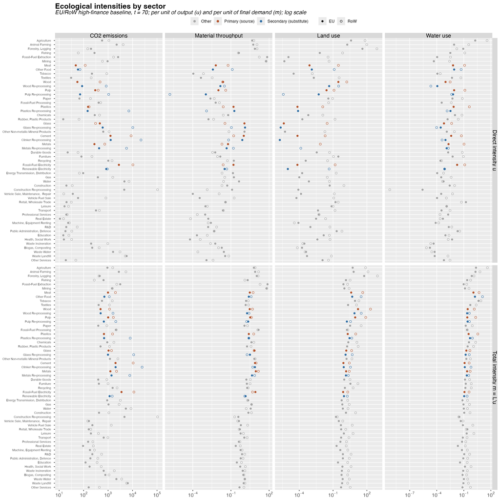

Figure 1: Direct (top) and total (bottom) intensities of the 54 sectors of each region, EU/RoW high-finance baseline at t = 70. Targeted primary sectors orange, substitutes blue; filled EU, open RoW; log scale. Land and water are in the workbook’s units, whose raw provenance is not fully traced; only comparisons across sectors are read.

Substitute-to-primary ratio of each targeted pair’s intensities (below 1, the substitution lowers the extension per unit moved). EU sectors unless marked RoW; t = 70.

| Pair | CO2, direct | CO2, total | Material, direct | Material, total | Land, total | Water, total | RoW CO2, total |
| --- | --- | --- | --- | --- | --- | --- | --- |
| Food (meat → other food) | 1.23 | 0.71 | 0.59 | 0.84 | 1.24 | 1.48 | 0.56 |
| Energy (fossil → renewable electricity) | 0.30 | 0.33 | 0.20 | 0.17 | 1.19 | 0.93 | 0.13 |
| Wood | 1.56 | 1.01 | 0.61 | 0.62 | 0.48 | 0.87 | 1.39 |
| Pulp | 0.24 | 0.67 | 0.10 | 0.70 | 0.18 | 1.08 | 1.26 |
| Plastics | 0.96 | 1.01 | 1.16 | 0.97 | 1.44 | 1.42 | 5.26 |
| Glass | 1.31 | 0.95 | 1.12 | 0.44 | 0.87 | 0.84 | 8.05 |
| Cement (clinker) | 1.02 | 1.01 | 0.77 | 0.98 | 1.07 | 1.05 | 2.32 |
| Metals | 1.55 | 1.11 | 0.78 | 0.50 | 0.96 | 0.93 | 3.48 |

## Dynamical analysis

**Which equations are simultaneous: the dependency graph and its core.** Write an edge $j \to i$ when equation $i$ reads the current value of $j$. The graph has cycles — output sets income, income sets demand, demand sets output — and its strongly connected components (maximal sets of variables each reaching every other) separate the cyclic part from the rest. Contracting each component to a vertex leaves a directed acyclic graph, the condensation, which orders the solution. Of its 1,955 components, 1,950 are single equations evaluated in sequence; one has 1,024 variables, the **simultaneous core**, identical in both setups. It contains, for each region, the 54-sector vectors of final demand, output, prices, employment, value added, the wage bill and sectoral incomes, with consumption, disposable income, investment, replacement, the capital stock, imports and tax revenues: the circular flow of the surplus approach, written as the Keynesian multiplier through the input–output system. This is the graph-theoretic form of Sraffa’s distinction between basic and non-basic commodities: the core is the basics, and everything else hangs off it as an acyclic tail. Joining the lagged reads shows that no ecological or distributional indicator returns to the core in any number of periods (Supplementary Appendix 4): **emissions, extraction, land, water and the income shares are non-basic; ecological damage is accounted, not transmitted.**

**How the system moves between periods: linearisation.** Linearising about the baseline path, $d\mathbf s_t = J_c\,d\mathbf s_t + J_\ell\,d\mathbf s_{t-1}$, so $d\mathbf s_t = M\,d\mathbf s_{t-1}$ with $M = (I - J_c)^{-1}J_\ell$. The first factor is a Leontief inverse across equations rather than sectors: the within-period multiplier, with no dynamics of its own. All the dynamics are in $J_\ell$, whose non-zero columns are the 1,079 lagged variables that actually move the next period’s solution, so the non-zero spectrum of $M$ is that of a square block of that size. $M$ is computed by finite differences of the full period solve. Its eigenvalues give the local modes: a real root inside the unit circle a monotone return, a complex pair a damped oscillation with period $2\pi/\arg\lambda$ and damping $|\lambda|$ per period, a unit root a stock that accumulates a flow.

**The damped cycle.** The EU/RoW baseline returns to rest through a damped cycle of about 22 periods (the calibration section shows the eight baselines). It is produced by the firm accelerator (3.2): with the speed of adjustment lowered from 0.15 to 0.05 and nothing else changed, the oscillation disappears. Investment that chases a capital target its own spending moves is the multiplier–accelerator interaction of Samuelson (1939), which yields converging oscillations over a wide range of coefficients. The North/South baseline, with the same behavioural coefficients, returns monotonically; the spectrum locates the difference.